# Regresi Linier

## Persiapan Data

DBR atau Debt Burden Ratio merupakan perbandingan antara cicilan utang dengan pendapatan bersih per bulan

### Struktur dan ringkasan data

```r
datamodul4 <- read.csv(file="https://github.com/alfanugraha/tsa-handson/raw/master/datalatih4.csv",
                header = T,
                sep = ",")
str(datamodul4)
```

```
'data.frame':   500 obs. of  19 variables:
 $ NAMA           : chr  "A123145" "A118717" "A125680" "A14798" ...
 $ EVENT          : int  36 48 24 60 24 24 60 36 60 18 ...
 $ STATUS         : chr  "NEW" "NEW" "NEW" "NEW" ...
 $ JK             : chr  "LAKI LAKI" "LAKI LAKI" "PEREMPUAN" "LAKI LAKI" ...
 $ USIA           : int  44 53 28 45 44 51 28 32 43 56 ...
 $ STATUS_NIKAH   : chr  "MENIKAH" "MENIKAH" "MENIKAH" "MENIKAH" ...
 $ JML_TANGGUNGAN : int  2 2 2 3 1 3 0 0 1 3 ...
 $ STATUS_TT      : chr  "Milik Sendiri" "Milik Sendiri" "Milik Sendiri" "Milik Sendiri" ...
 $ PENDIDIKAN     : chr  "SMA" "SMA" "SMA" "SMA" ...
 $ WILAYAH        : chr  "Balikpapan" "Balikpapan" "Balikpapan" "Medan" ...
 $ PEKERJAAN      : chr  "Pegawai swasta" "Pegawai BUMN" "Pegawai swasta" "Pegawai swasta" ...
 $ LAMA_BEKERJA   : int  14 25 6 15 3 10 5 1 3 10 ...
 $ PENGHASILAN    : int  2829819 23757496 2733000 3000000 4195200 8883124 4943520 3749812 5000000 10672327 ...
 $ DBR            : num  0.45 0.37 0.45 0.42 0.35 0.49 0.51 0.23 0.2 0.15 ...
 $ WAKTU_KREDIT   : int  36 48 24 60 24 24 60 36 60 18 ...
 $ LIMIT_KREDIT   : int  23000000 300000000 16000000 50000000 28000000 90000000 100000000 18500000 40000000 25000000 ...
 $ STATUS_KREDIT  : chr  "LANCAR" "LANCAR" "LANCAR" "LANCAR" ...
 $ PENDIDIKAN_KODE: int  3 3 3 3 5 3 4 5 3 3 ...
 $ PENDIDIKAN2    : chr  "3. SMA" "3. SMA" "3. SMA" "3. SMA" ...
```

|  | NAMA | EVENT | STATUS | JK | USIA | STATUS_NIKAH | JML_TANGGUNGAN | STATUS_TT | PENDIDIKAN | WILAYAH | PEKERJAAN | LAMA_BEKERJA | PENGHASILAN | DBR | WAKTU_KREDIT | LIMIT_KREDIT | STATUS_KREDIT | PENDIDIKAN_KODE | PENDIDIKAN2 |
| --- | --- | --- | --- | --- | --- | --- | --- | --- | --- | --- | --- | --- | --- | --- | --- | --- | --- | --- | --- |
| 1 | A123145 | 36 | NEW | LAKI LAKI | 44 | MENIKAH | 2 | Milik Sendiri | SMA | Balikpapan | Pegawai swasta | 14 | 2829819 | 0.45 | 36 | 23000000 | LANCAR | 3 | 3. SMA |
| 2 | A118717 | 48 | NEW | LAKI LAKI | 53 | MENIKAH | 2 | Milik Sendiri | SMA | Balikpapan | Pegawai BUMN | 25 | 23757496 | 0.37 | 48 | 300000000 | LANCAR | 3 | 3. SMA |
| 3 | A125680 | 24 | NEW | PEREMPUAN | 28 | MENIKAH | 2 | Milik Sendiri | SMA | Balikpapan | Pegawai swasta | 6 | 2733000 | 0.45 | 24 | 16000000 | LANCAR | 3 | 3. SMA |
| 4 | A14798 | 60 | NEW | LAKI LAKI | 45 | MENIKAH | 3 | Milik Sendiri | SMA | Medan | Pegawai swasta | 15 | 3000000 | 0.42 | 60 | 50000000 | LANCAR | 3 | 3. SMA |
| 5 | A142852 | 24 | NEW | PEREMPUAN | 44 | MENIKAH | 1 | Milik Orang Tua | S1 | Jakarta 5 | Pegawai swasta | 3 | 4195200 | 0.35 | 24 | 28000000 | LANCAR | 5 | 5. S1 |
| 6 | A96802 | 24 | NEW | PEREMPUAN | 51 | MENIKAH | 3 | Milik Sendiri | SMA | Jakarta 4 | PNS | 10 | 8883124 | 0.49 | 24 | 90000000 | LANCAR | 3 | 3. SMA |

```r
skimr::skim(datamodul4)
```

[output not shown]

|  | skim_variable | n_missing | complete_rate | min | max | empty | n_unique | whitespace |
| --- | --- | --- | --- | --- | --- | --- | --- | --- |
| 1 | NAMA | 0 | 1 | 4 | 7 | 0 | 500 | 0 |
| 2 | STATUS | 0 | 1 | 3 | 3 | 0 | 2 | 0 |
| 3 | JK | 0 | 1 | 9 | 9 | 0 | 2 | 0 |
| 4 | STATUS_NIKAH | 0 | 1 | 5 | 13 | 0 | 3 | 0 |
| 5 | STATUS_TT | 0 | 1 | 4 | 15 | 0 | 5 | 0 |
| 6 | PENDIDIKAN | 0 | 1 | 2 | 7 | 0 | 6 | 0 |
| 7 | WILAYAH | 0 | 1 | 5 | 10 | 0 | 12 | 0 |
| 8 | PEKERJAAN | 0 | 1 | 3 | 14 | 0 | 3 | 0 |
| 9 | STATUS_KREDIT | 0 | 1 | 5 | 6 | 0 | 2 | 0 |
| 10 | PENDIDIKAN2 | 0 | 1 | 5 | 10 | 0 | 6 | 0 |

[output not shown]

|  | skim_variable | n_missing | complete_rate | mean | sd | p0 | p25 | p50 | p75 | p100 | hist |
| --- | --- | --- | --- | --- | --- | --- | --- | --- | --- | --- | --- |
| 1 | EVENT | 0 | 1 | 4.534400e+01 | 2.849782e+01 | 6.00 | 24.00 | 36.00 | 60.00 | 120.0 | ▇▇▅▂▁ |
| 2 | USIA | 0 | 1 | 3.654000e+01 | 8.594424e+00 | 22.00 | 30.00 | 34.00 | 43.00 | 59.0 | ▆▇▆▃▂ |
| 3 | JML_TANGGUNGAN | 0 | 1 | 1.472000e+00 | 1.265076e+00 | 0.00 | 0.00 | 1.00 | 2.00 | 5.0 | ▇▅▂▁▁ |
| 4 | LAMA_BEKERJA | 0 | 1 | 7.892000e+00 | 6.674837e+00 | 1.00 | 3.00 | 6.00 | 11.00 | 29.0 | ▇▃▁▁▁ |
| 5 | PENGHASILAN | 0 | 1 | 6.387706e+06 | 5.976688e+06 | 2005020.00 | 3437853.50 | 4594916.00 | 7021339.25 | 65459300.0 | ▇▁▁▁▁ |
| 6 | DBR | 0 | 1 | 3.482400e-01 | 1.333464e-01 | 0.04 | 0.25 | 0.34 | 0.44 | 0.6 | ▂▆▇▆▅ |
| 7 | WAKTU_KREDIT | 0 | 1 | 5.553600e+01 | 2.872760e+01 | 12.00 | 36.00 | 48.00 | 60.00 | 120.0 | ▃▇▆▃▂ |
| 8 | LIMIT_KREDIT | 0 | 1 | 7.435900e+07 | 7.953267e+07 | 5000000.00 | 25000000.00 | 40000000.00 | 95500000.00 | 517000000.0 | ▇▁▁▁▁ |

Karena terdapat peubah kategorik yang terbaca sebagai numerik, maka dilakukan konversi terlebih dahulu

```r
datamodul4$PENDIDIKAN_KODE <- as.factor(datamodul4$PENDIDIKAN_KODE)
```

Melihat statistik deskriptif dari data

```r
summary(datamodul4)
```

```
     NAMA               EVENT           STATUS               JK                 USIA       STATUS_NIKAH       JML_TANGGUNGAN
 Length:500         Min.   :  6.00   Length:500         Length:500         Min.   :22.00   Length:500         Min.   :0.000
 Class :character   1st Qu.: 24.00   Class :character   Class :character   1st Qu.:30.00   Class :character   1st Qu.:0.000
 Mode  :character   Median : 36.00   Mode  :character   Mode  :character   Median :34.00   Mode  :character   Median :1.000
                    Mean   : 45.34                                         Mean   :36.54                      Mean   :1.472
                    3rd Qu.: 60.00                                         3rd Qu.:43.00                      3rd Qu.:2.000
                    Max.   :120.00                                         Max.   :59.00                      Max.   :5.000
  STATUS_TT          PENDIDIKAN          WILAYAH           PEKERJAAN          LAMA_BEKERJA     PENGHASILAN
 Length:500         Length:500         Length:500         Length:500         Min.   : 1.000   Min.   : 2005020
 Class :character   Class :character   Class :character   Class :character   1st Qu.: 3.000   1st Qu.: 3437854
 Mode  :character   Mode  :character   Mode  :character   Mode  :character   Median : 6.000   Median : 4594916
                                                                             Mean   : 7.892   Mean   : 6387706
                                                                             3rd Qu.:11.000   3rd Qu.: 7021339
                                                                             Max.   :29.000   Max.   :65459300
      DBR          WAKTU_KREDIT     LIMIT_KREDIT       STATUS_KREDIT      PENDIDIKAN_KODE PENDIDIKAN2
 Min.   :0.0400   Min.   : 12.00   Min.   :  5000000   Length:500         1:  1           Length:500
 1st Qu.:0.2500   1st Qu.: 36.00   1st Qu.: 25000000   Class :character   2:  4           Class :character
 Median :0.3400   Median : 48.00   Median : 40000000   Mode  :character   3:247           Mode  :character
 Mean   :0.3482   Mean   : 55.54   Mean   : 74359000                      4: 95
 3rd Qu.:0.4400   3rd Qu.: 60.00   3rd Qu.: 95500000                      5:144
 Max.   :0.6000   Max.   :120.00   Max.   :517000000                      6:  9
```

### Korelasi antar peubah

Untuk melihat korelasi antara 2 peubah dapat menggunakan fungsi `cor` Jika ingin menghitung korelasi Spearman khususnya pada data rank, maka dapat mengatur argumen untuk parameter `method` dengan nilai `"spearman"`.

```r
cat("*************** KORELASI ***************\n\n")
```

```
*************** KORELASI ***************
```

```r
cat(" Penghasilan & Limit Kredit -->",
    round(cor(datamodul4$PENGHASILAN, datamodul4$LIMIT_KREDIT), 3), "\n",
    "Penghasilan & Lama Bekerja -->",
    round(cor(datamodul4$PENGHASILAN, datamodul4$LAMA_BEKERJA), 3), "\n",
    "Waktu kredit & Limit Kredit -->",
    round(cor(datamodul4$WAKTU_KREDIT, datamodul4$LIMIT_KREDIT), 3), "\n",
    "Pendidikan & Penghasilan -->",
    round(cor(as.integer(datamodul4$PENDIDIKAN_KODE), datamodul4$PENGHASILAN, method ="spearman"), 3), "\n",
    "Pendidikan & Limit Kredit -->",
    round(cor(as.integer(datamodul4$PENDIDIKAN_KODE), datamodul4$LIMIT_KREDIT, method ="spearman"), 3),"\n",
    "Usia & Lama Bekerja -->",
    round(cor(datamodul4$USIA, datamodul4$LAMA_BEKERJA), 3), "\n",

"\n****************************************\n")
```

```
 Penghasilan & Limit Kredit --> 0.628
 Penghasilan & Lama Bekerja --> 0.185
 Waktu kredit & Limit Kredit --> 0.593
 Pendidikan & Penghasilan --> 0.222
 Pendidikan & Limit Kredit --> 0.124
 Usia & Lama Bekerja --> 0.653
```

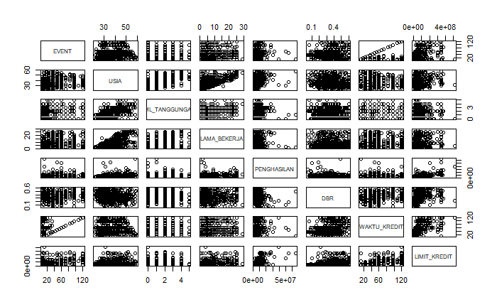

Membuat matriks korelasi untuk setiap peubah numerik

```r
corr_matx <- datamodul4 %>% select_if(is.numeric) %>% cor() %>% round(3)
corr_matx
```

```
               EVENT   USIA JML_TANGGUNGAN LAMA_BEKERJA PENGHASILAN    DBR WAKTU_KREDIT LIMIT_KREDIT
EVENT          1.000  0.070          0.055        0.111       0.095  0.122        0.578        0.339
USIA           0.070  1.000          0.618        0.653       0.301 -0.088       -0.047        0.197
JML_TANGGUNGAN 0.055  0.618          1.000        0.437       0.159 -0.116        0.016        0.089
LAMA_BEKERJA   0.111  0.653          0.437        1.000       0.185 -0.021        0.096        0.243
PENGHASILAN    0.095  0.301          0.159        0.185       1.000 -0.147        0.080        0.628
DBR            0.122 -0.088         -0.116       -0.021      -0.147  1.000        0.372        0.344
WAKTU_KREDIT   0.578 -0.047          0.016        0.096       0.080  0.372        1.000        0.593
LIMIT_KREDIT   0.339  0.197          0.089        0.243       0.628  0.344        0.593        1.000
```

Menampilkan nilai korelasi dalam bentuk grafis menggunakan `corrplot`

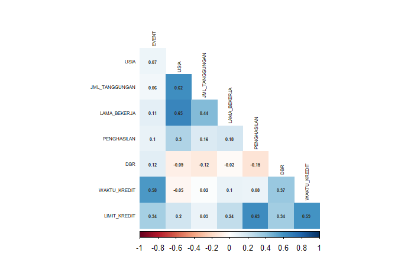

```r
corrplot(corr_matx,
         method = "color",
         type = "lower",
         tl.cex = 0.5,
         tl.col = "black",
         addCoef.col = "#2F2F2F",
         addCoefasPercent = FALSE,
         number.cex = 0.5,
         diag=F)
```

## Regresi Linier Sederhana

Model regresi linear sederhana yaitu model regresi dimana terdapat 1 peubah respon dengan hanya 1 peubah penjelas. Contohnya, model untuk menghitung LIMIT KREDIT, sebagai peubah respon (Y), berdasarkan informasi mengenai PENGHASILAN, sebagai peubah penjelas (X)

| LIMIT_KREDIT | PENGHASILAN |
| --- | --- |
| 23000000 | 2829819 |
| 300000000 | 23757496 |
| 16000000 | 2733000 |
| 50000000 | 3000000 |
| 28000000 | 4195200 |
| 90000000 | 8883124 |
| 100000000 | 4943520 |
| 18500000 | 3749812 |
| 40000000 | 5000000 |
| 25000000 | 10672327 |

[output cut: 490 more lines]

### Membangun model regresi linier sederhana

```r
reg1 <- lm(LIMIT_KREDIT ~ PENGHASILAN, data = data_reg1)

summary(reg1)
```

```
Call:
lm(formula = LIMIT_KREDIT ~ PENGHASILAN, data = data_reg1)

Residuals:
       Min         1Q     Median         3Q        Max
-241548318  -30563160  -19034577   15820323  253846561

Coefficients:
             Estimate Std. Error t value Pr(>|t|)
(Intercept) 2.101e+07  4.059e+06   5.177 3.28e-07 ***
PENGHASILAN 8.351e+00  4.643e-01  17.988  < 2e-16 ***
---
Signif. codes:  0 ‘***’ 0.001 ‘**’ 0.01 ‘*’ 0.05 ‘.’ 0.1 ‘ ’ 1

Residual standard error: 61980000 on 498 degrees of freedom
Multiple R-squared:  0.3938,    Adjusted R-squared:  0.3926
F-statistic: 323.6 on 1 and 498 DF,  p-value: < 2.2e-16
```

Berdasarkan summary model, dapat diketahui bahwa peubah PENGHASILAN memiliki pengaruh yang signifikan di dalam model (`p-value` sangat kecil `***`). Namun, jika dilihat dari nilai $R^2$ , sepertinya performa model belum cukup baik dimana Peubah PENGHASILAN hanya mampu menjelaskan sekitar 39% keragaman dari peubah respon.

### Plot garis regresi

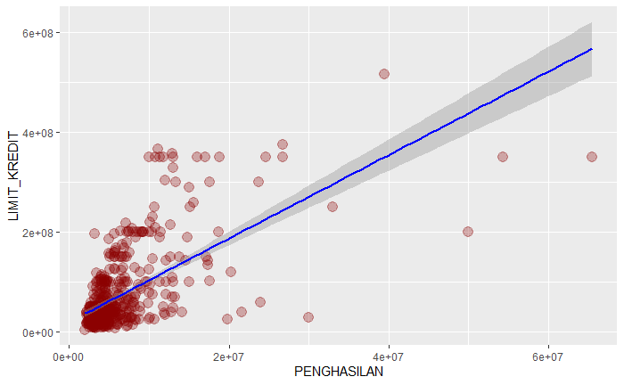

```r
# Membuat scatter plot
scatter_plot <- ggplot(data = data_reg1, aes(x = PENGHASILAN, y = LIMIT_KREDIT)) +
  # Menambahkan titik-titik scatter plot
  geom_point(color="darkred", size=4, alpha=0.3) +
  # Menambahkan garis regresi
  geom_smooth(method = "lm",
              formula = y ~ x,
              se = T, # Menambahkan C.I
              color = "blue")

# Menampilkan scatter plot
scatter_plot
```

Jika melihat plot pencaran, tidak tergambarkan secara jelas hubungan antara peubah PENGHASILAN dan LIMIT_KREDIT. Sebagian besar data menumpuk pada nilai-nilai kecil, namun ada data-data lainnya yang menyebar pada rentang nilai yang sangat besar. Hal ini mengindikasikan juga bahwa terdapat kemenjuluran yang besar pada kedua peubah serta kemungkinan besar asumsi-asumsi model linear tidak terpenuhi.

### Normal Q-Q Plot

Dari Normal Q-Q Plot maupun uji formal menggunakan Shapiro-Wilk maka dapat disimpulkan dengan sangat jelas bahwa residual model tidak menyebar normal.

Asumsi normalitas pada model regresi linier: residual menyebar $Normal(0, \sigma^2)$

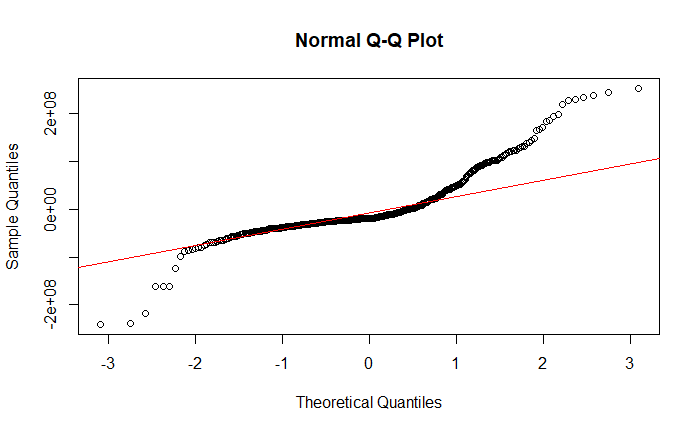

```r
# Menghitung nilai residual dari model reg1
res <- residuals(reg1)

# Membuat Kurva Normal QQ Plot
qqnorm(res)
qqline(res, col="red")
```

```r
# Mengecek apakah residual menyebar Normal
shapiro.test(res)
```

```
    Shapiro-Wilk normality test

data:  res
W = 0.84589, p-value < 2.2e-16
```

### Shapiro-Wilk test

Menguji apakah sisaan (residual) menyebar normal

```r
shapiro.test(res)
```

```
    Shapiro-Wilk normality test

data:  res
W = 0.84589, p-value < 2.2e-16
```

### Plot sisaan

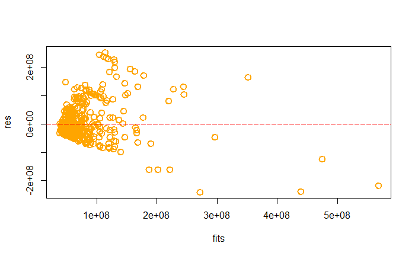

```r
fits <- fitted(reg1)
plot(fits, res, col="orange", cex=1.5, lwd=2)
abline(h=0, col="red", lty=5)
```

- nilai sisaan tidak menyebar secara acak
- membentuk pola seperti corong mengindikasikan bahwa semakin besar nilai Y maka sisaannya semakin besar

### Uji Homogenitas

```r
library(car)
ncvTest(reg1)
```

```
Non-constant Variance Score Test
Variance formula: ~ fitted.values
Chisquare = 464.2134, Df = 1, p = < 2.22e-16
```

### Uji autokorelasi

Uji Durbin-Watson

```r
library(lmtest)
dwtest(reg1)
```

```
    Durbin-Watson test

data:  reg1
DW = 1.9919, p-value = 0.4643
alternative hypothesis: true autocorrelation is greater than 0
```

## Model regresi linier dengan transformasi (LOG)

```r
data_reg2 <- log(data_reg1)
data_reg2
```

| LIMIT_KREDIT | PENGHASILAN |
| --- | --- |
| 16.95100 | 14.85572 |
| 19.51929 | 16.98341 |
| 16.58810 | 14.82091 |
| 17.72753 | 14.91412 |
| 17.14772 | 15.24945 |
| 18.31532 | 15.99966 |
| 18.42068 | 15.41359 |
| 16.73328 | 15.13722 |
| 17.50439 | 15.42495 |
| 17.03439 | 16.18316 |

[output cut: 490 more lines]

```r
# Y ~ X1 + X2 + X3
reg2 <- lm(LIMIT_KREDIT ~ PENGHASILAN, data_reg2)
summary(reg2)
```

```
Call:
lm(formula = LIMIT_KREDIT ~ PENGHASILAN, data = data_reg2)

Residuals:
     Min       1Q   Median       3Q      Max
-2.22586 -0.44672 -0.05501  0.51649  1.86892

Coefficients:
            Estimate Std. Error t value Pr(>|t|)
(Intercept)  2.34445    0.83985   2.792  0.00545 **
PENGHASILAN  0.99311    0.05427  18.299  < 2e-16 ***
---
Signif. codes:  0 ‘***’ 0.001 ‘**’ 0.01 ‘*’ 0.05 ‘.’ 0.1 ‘ ’ 1

Residual standard error: 0.6872 on 498 degrees of freedom
Multiple R-squared:  0.4021,    Adjusted R-squared:  0.4009
F-statistic: 334.9 on 1 and 498 DF,  p-value: < 2.2e-16
```

QQ Plot

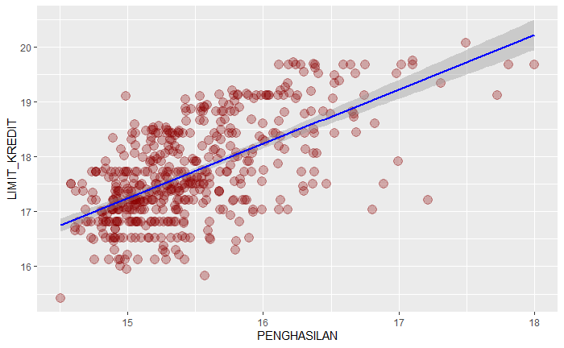

```r
ggplot(data=data_reg2, aes(x=PENGHASILAN, y=LIMIT_KREDIT)) +
  # menambahkan titik amatan
  geom_point(color="darkred", size=4, alpha=0.3) +
  # menambahkan garis regresi
  geom_smooth(method = "lm",
              formula = y ~ x,
              se = T, # menambahkan selang kepercayaan
              color = "blue")
```

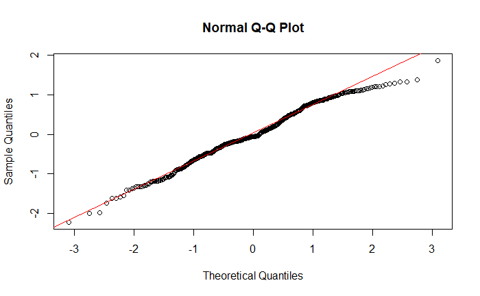

```r
# mengambil sisaan dari model reglin
res2 <- residuals(reg2)

# membuat kurva normal Q-Q plot
qqnorm(res2)
qqline(res2, col="red")
```

```r
shapiro.test(res2)
```

```
    Shapiro-Wilk normality test

data:  res2
W = 0.98735, p-value = 0.0002497
```

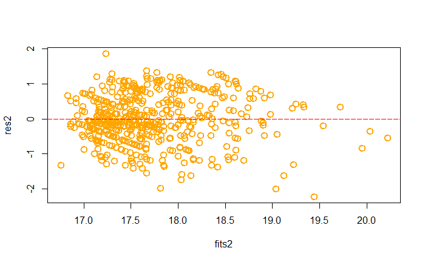

```r
# plot sisaan
fits2 <- fitted(reg2)
plot(fits2, res2, col="orange", cex=1.5, lwd=2)
abline(h=0, col="red", lty=5)
```

## Prediksi

Tujuan lain dari membangun suatu model untuk melakukan prediksi

```r
# contoh terdapat dua orang baru sebagai amatan dengan penghasilan berbeda
income <- data.frame("PENGHASILAN"=c(15000000, 9000000))

# prediksi pada model regresi linier tanpa transformasi
pred_reg1 <- predict(reg1, income)
t(pred_reg1)
```

```
             1        2
[1,] 146281380 96174605
```

```r
# prediksi pada model regresi linier dengan transformasi
pred_reg2 <- predict(reg2, income)
t(pred_reg2)
```

```
            1       2
[1,] 14896687 8938013
```

## Regresi linear berganda

- Hasil sebelumnya $R^2$ tidak begitu tinggi
- Indikasinya perlu tambahan peubah penjelas lain agar dapat menjelaskan keragaman peubah Y dengan lebih baik

```r
nama_col <- c("LIMIT_KREDIT", "PENGHASILAN", "PEKERJAAN", "LAMA_BEKERJA", "STATUS_TT",
             "USIA", "STATUS_NIKAH", "JML_TANGGUNGAN", "WAKTU_KREDIT")
data_mul1 <- datamodul4[nama_col]
head(data_mul1)
```

|  | LIMIT_KREDIT | PENGHASILAN | PEKERJAAN | LAMA_BEKERJA | STATUS_TT | USIA | STATUS_NIKAH | JML_TANGGUNGAN | WAKTU_KREDIT |
| --- | --- | --- | --- | --- | --- | --- | --- | --- | --- |
| 1 | 23000000 | 2829819 | Pegawai swasta | 14 | Milik Sendiri | 44 | MENIKAH | 2 | 36 |
| 2 | 300000000 | 23757496 | Pegawai BUMN | 25 | Milik Sendiri | 53 | MENIKAH | 2 | 48 |
| 3 | 16000000 | 2733000 | Pegawai swasta | 6 | Milik Sendiri | 28 | MENIKAH | 2 | 24 |
| 4 | 50000000 | 3000000 | Pegawai swasta | 15 | Milik Sendiri | 45 | MENIKAH | 3 | 60 |
| 5 | 28000000 | 4195200 | Pegawai swasta | 3 | Milik Orang Tua | 44 | MENIKAH | 1 | 24 |
| 6 | 90000000 | 8883124 | PNS | 10 | Milik Sendiri | 51 | MENIKAH | 3 | 24 |

```r
reg_mul1 <- lm(LIMIT_KREDIT ~ ., data_mul1)
summary(reg_mul1)
```

```
Call:
lm(formula = LIMIT_KREDIT ~ ., data = data_mul1)

Residuals:
       Min         1Q     Median         3Q        Max
-205151888  -19357136   -1433490   15484055  185612046

Coefficients:
                            Estimate Std. Error t value Pr(>|t|)
(Intercept)               -1.035e+08  3.624e+07  -2.856  0.00448 **
PENGHASILAN                7.568e+00  3.621e-01  20.898  < 2e-16 ***
PEKERJAANPegawai swasta   -1.530e+07  7.305e+06  -2.094  0.03678 *
PEKERJAANPNS              -2.725e+07  9.223e+06  -2.954  0.00329 **
LAMA_BEKERJA               1.177e+06  3.970e+05   2.963  0.00319 **
STATUS_TTMilik Orang Tua   1.717e+07  3.252e+07   0.528  0.59771
STATUS_TTMilik Sendiri     1.602e+07  3.261e+07   0.491  0.62344
STATUS_TTRumah Dinas       3.044e+07  3.312e+07   0.919  0.35852
STATUS_TTSewa              2.119e+07  3.277e+07   0.647  0.51820
USIA                       3.648e+05  3.638e+05   1.003  0.31656
STATUS_NIKAHMENIKAH        2.546e+07  2.102e+07   1.211  0.22655
STATUS_NIKAHTIDAK MENIKAH  2.913e+07  2.138e+07   1.362  0.17375
JML_TANGGUNGAN            -3.824e+06  2.251e+06  -1.699  0.09004 .
WAKTU_KREDIT               1.500e+06  7.120e+04  21.064  < 2e-16 ***
---
Signif. codes:  0 ‘***’ 0.001 ‘**’ 0.01 ‘*’ 0.05 ‘.’ 0.1 ‘ ’ 1

Residual standard error: 43310000 on 486 degrees of freedom
Multiple R-squared:  0.7111,    Adjusted R-squared:  0.7034
F-statistic: 92.04 on 13 and 486 DF,  p-value: < 2.2e-16
```